# 光场的量子涨落：从相干态到压缩光

量子光学导论 · 第十讲

光场的量子涨落

从相干态到压缩光

李梓民 · 中南大学物理学院

zimin.li@csu.edu.cn

# 本讲导读

**真空里没有光子，反复测电场，读数还是会起伏。换一种光来测，读数能比这更稳吗？**

1. 01

### 从光子计数到电场相位

   光子数分布一样，两束光的波峰也可能错开。分别与同一束参考光干涉，就能看出差别。
2. 02

### 两个场分量与真空涨落

   调节参考光的相位，可以分别测电场的余弦和正弦分量。在真空中，两种读数的起伏一样大。
3. 03

### 从热光到压缩光

   热光的两个分量都比真空起伏大。压缩光让一个比真空更稳，另一个起伏更大。
4. 04

### 用零拍探测测量噪声

   固定参考光的相位，反复测两只探测器的计数差。差值比测真空时更集中，就看到了压缩。
5. 05

### 压缩光的产生与损耗

   用激光照射晶体，让光子成对产生，可以制备压缩光。途中损耗越大，测到的压缩越弱。
6. 06

### 引力波干涉仪中的压缩光

   引力波会使两条臂的长度差发生微小变化。用上压缩光，LIGO 就能把这样的变化看得更清楚。

# 从光子计数到电场相位

目录

CONTENTS

第七讲里，真空的光子数总是零，电场读数却有起伏。要比较电场的涨落，先用两束熟悉的相干光检验：只记录光子数，能分辨它们的电场吗？

# 比较两束相干光的光子数和平均电场

同一模式、同一相位参考下，两束相干光的振幅为 $\alpha_A=1$（蓝）和 $\alpha_B=i$（棕）。

**数光子**

两束光都有 $|\alpha|^2=1$，因此每个 $n$ 的概率都相同：$P_A(n)=P_B(n)=e^{-1}/n!$。

[figure not shown]

**测平均电场**

平均电场正比于 $\operatorname{Re}(\alpha e^{-i\omega t})$。代入两束光的振幅，A 得到余弦，B 得到正弦。

同一时刻 $t=0$，A 在波峰，B 正经过零点。光子数分布相同，平均电场仍然可以不同。

# 思考题 1 相同的计数统计

两个相干态分别满足 $\alpha_A=1$、$\alpha_B=i$。两者的平均光子数均为1。哪一项正确？

$P_\alpha(n)=e^{-|\alpha|^2}|\alpha|^{2n}/n!$，相位以同一参考光定义。

B。$P(n)$ 只依赖 $|\alpha|^2$。相位差使两条平均电场曲线错开四分之一个周期。

# 同一束参考光把相位差变成计数差

单独数光子分不出 A 和 B。让它们分别与同一束参考光干涉，就能比较两者的相位。

[figure not shown]

**让两束光相遇。** 信号光 $a$ 从一侧入射，另一侧送入同频的强相干参考光 $b$。这束参考光叫作**本振光**（local oscillator），它的相位可以调节。

**看两个出口。** 每个出口都有两束光叠加。调节本振相位时，一路因干涉变亮，另一路就变暗。

同一时间窗内，记录计数差 $D=n_c-n_d$。这种测法叫作**平衡零拍探测**（balanced homodyne detection）。

# 从两路光子数算出计数差

沿用第九讲的 50:50 分束器约定：信号 $a$ 与本振 $b$ 等权叠加，在 $c$ 端取和，在 $d$ 端取差。探测器测量各输出模式的光子数：

$$\begin{aligned}
\hat c &= (\hat a+\hat b)/\sqrt{2}, &\qquad \hat n_c &= \hat c^\dagger\hat c = \tfrac12(\hat a^\dagger+\hat b^\dagger)(\hat a+\hat b),\\
\hat d &= (\hat a-\hat b)/\sqrt{2}, &\qquad \hat n_d &= \hat d^\dagger\hat d = \tfrac12(\hat a^\dagger-\hat b^\dagger)(\hat a-\hat b).
\end{aligned}$$

展开两个乘积。两路的输入光子数项相同，干涉项的符号相反。

$$\begin{aligned}
2\hat n_c &= (\hat a^\dagger\hat a+\hat b^\dagger\hat b) + (\hat a^\dagger\hat b+\hat b^\dagger\hat a),\\
2\hat n_d &= (\hat a^\dagger\hat a+\hat b^\dagger\hat b) - (\hat a^\dagger\hat b+\hat b^\dagger\hat a).
\end{aligned}$$

用 $c$ 路减去 $d$ 路，共同的光子数项抵消，符号相反的干涉项相加。

$$\hat D=\hat n_c-\hat n_d=\hat a^\dagger\hat b+\hat b^\dagger\hat a.$$

## 单光子从一个入口到达两个出口

要算两束光同时入射时的计数差，先找出每个入口通往两个出口的概率幅。暂时关掉本振，只从 $a$ 端送入一个光子。输入态 $|1,0\rangle_{ab}$ 中的两个数依次表示 $a,b$ 端的光子数。

**一次测量只有一只探测器响。** 50:50 分束器使光子到达 $c,d$ 两端的概率各为一半。概率是概率幅的模平方，因此
$$P(c|a)=P(d|a)=\tfrac12,\qquad |A_{c|a}|=|A_{d|a}|=1/\sqrt2.$$

探测前，两条输出路径保持相干。沿用第九讲的端口相位约定，从 $a$ 入射时两个幅都取正，输出态为
$$|\psi_a\rangle=\frac{|1,0\rangle_{cd}+|0,1\rangle_{cd}}{\sqrt2}.$$

## 从另一个入口入射时的单光子输出态

改从 $b$ 端送入一个光子。记到两个出口的概率幅为 $u,v$。两端仍等概率，故 $|u|=|v|=1/\sqrt2$。
$$\begin{aligned}
a\text{ 端入射}\quad |\psi_a\rangle&=(|1,0\rangle_{cd}+|0,1\rangle_{cd})/\sqrt2,\\
b\text{ 端入射}\quad |\psi_b\rangle&=u|1,0\rangle_{cd}+v|0,1\rangle_{cd}.
\end{aligned}$$

两种输入态 $|1,0\rangle_{ab}$ 和 $|0,1\rangle_{ab}$ 正交。无损分束器保持内积，因此两个输出态也必须正交：
$$\langle\psi_a|\psi_b\rangle=\frac{u+v}{\sqrt2}=0\quad\Longrightarrow\quad v=-u.$$

选取整体相位使 $u=1/\sqrt2$，则 $|\psi_b\rangle=(|1,0\rangle_{cd}-|0,1\rangle_{cd})/\sqrt2$。负号表示两条输出路径的概率幅相差 $\pi$ 的相位。

## 把单光子输出态写成产生算符作用于真空

记输出真空为 $|0\rangle_{\rm out}=|0,0\rangle_{cd}$。分别在 $c$ 路、$d$ 路增加一个光子：
$$|1,0\rangle_{cd}=\hat c^\dagger|0\rangle_{\rm out},\qquad
|0,1\rangle_{cd}=\hat d^\dagger|0\rangle_{\rm out}.$$

**从 $a$ 入射。** 输入态是 $\hat a^\dagger|0\rangle_{\rm in}$。将上面两式代入输出的和态，提出共同的真空态：
$$|\psi_a\rangle=\tfrac1{\sqrt2}\big(\hat c^\dagger|0\rangle_{\rm out}+\hat d^\dagger|0\rangle_{\rm out}\big)
=\tfrac1{\sqrt2}(\hat c^\dagger+\hat d^\dagger)|0\rangle_{\rm out}.$$

**从 $b$ 入射。** 输入态是 $\hat b^\dagger|0\rangle_{\rm in}$。代入输出的差态，负号也保留在算符之间：
$$|\psi_b\rangle=\tfrac1{\sqrt2}\big(\hat c^\dagger|0\rangle_{\rm out}-\hat d^\dagger|0\rangle_{\rm out}\big)
=\tfrac1{\sqrt2}(\hat c^\dagger-\hat d^\dagger)|0\rangle_{\rm out}.$$

线性分束器保持真空，每个输入产生算符变为 $s\hat c^\dagger+t\hat d^\dagger$。这个组合在输出真空上产生的两个基态的系数就是 $s,t$。对照上面两行得
$$\hat a^\dagger\longrightarrow(\hat c^\dagger+\hat d^\dagger)/\sqrt2,\qquad
\hat b^\dagger\longrightarrow(\hat c^\dagger-\hat d^\dagger)/\sqrt2.$$

## 由输入模式求两路输出的湮灭算符

刚才沿光路写出了两个输入分别通往哪里。探测器固定在 $c,d$ 端，要算各自的计数，就反过来找出每个出口对应的输入组合：
$$\hat a^\dagger\longrightarrow(\hat c^\dagger+\hat d^\dagger)/\sqrt2,\qquad
\hat b^\dagger\longrightarrow(\hat c^\dagger-\hat d^\dagger)/\sqrt2.$$

上面两式相加，$\hat d^\dagger$ 项抵消；相减，$\hat c^\dagger$ 项抵消。将两组输入各除以 $\sqrt2$，得到
$$\begin{aligned}
(\hat a^\dagger+\hat b^\dagger)/\sqrt2 &\longrightarrow
\tfrac12\big[(\hat c^\dagger+\hat d^\dagger)+(\hat c^\dagger-\hat d^\dagger)\big]=\hat c^\dagger,\\
(\hat a^\dagger-\hat b^\dagger)/\sqrt2 &\longrightarrow
\tfrac12\big[(\hat c^\dagger+\hat d^\dagger)-(\hat c^\dagger-\hat d^\dagger)\big]=\hat d^\dagger.
\end{aligned}$$

取厄米共轭：$(\hat c^\dagger)^\dagger=\hat c$，实系数的正负号保留。用输入算符表示两只探测器所接的输出模式，得到
$$\hat c=(\hat a+\hat b)/\sqrt2,\qquad \hat d=(\hat a-\hat b)/\sqrt2.$$

# 平均计数差取决于信号与本振的相位差

上一页得到 $\hat D=\hat a^\dagger\hat b+\hat b^\dagger\hat a$。现在让信号与本振分别处于独立的相干态 $|\alpha\rangle$、$|\beta\rangle$。

**先取平均。** 两个模式独立，乘积的平均值可以分开算：
$$\langle\hat a^\dagger\hat b\rangle=\alpha^*\beta,\qquad
\langle\hat b^\dagger\hat a\rangle=\beta^*\alpha.$$

**再看相位。** 写成 $\alpha=|\alpha|e^{i\phi}$、$\beta=|\beta|e^{i\theta}$。两个干涉项互为共轭，相加得到两倍的实部。

两束光的振幅大小固定时，平均计数差随相位差按余弦变化。
$$\langle\hat D\rangle=2\operatorname{Re}(\beta^*\alpha)
=2|\alpha||\beta|\cos(\phi-\theta).$$

取同相输入 $\alpha=1$、$\beta=3$。两束光的振幅在 $c$ 路相加，在 $d$ 路相减。
$$\langle n_c\rangle=\frac{|1+3|^2}{2}=8,\qquad
\langle n_d\rangle=\frac{|1-3|^2}{2}=2,\qquad
\langle\hat D\rangle=8-2=6.$$

# 转动本振，看两路平均计数怎样变化

两束信号光分别与同一本振 $\beta=3e^{i\theta}$ 干涉。柱高表示两个输出端的平均光子数：
$$\langle n_c\rangle=\tfrac12|\alpha+\beta|^2,\qquad
\langle n_d\rangle=\tfrac12|\alpha-\beta|^2,\qquad
\langle D\rangle=\langle n_c\rangle-\langle n_d\rangle.$$

### 信号 A $\alpha=1$

$\langle\hat D\rangle=6\cos\theta$

### 信号 B $\alpha=i$

$\langle\hat D\rangle=6\sin\theta$

本振相位 $\theta$ 0°

# 思考题 2 本振相位与平均计数差

信号态为 $\alpha=i$，本振振幅为 $\beta=5e^{i\theta}$。当 $\theta=\pi/2$ 时，平均计数差是多少？

$\langle D\rangle=2|\alpha||\beta|\cos(\arg\alpha-\theta)$。

C。信号与本振同相，平均计数差为 $2\times1\times5=10$。也可分别算两路：$\langle n_c\rangle=(1+5)^2/2=18$，$\langle n_d\rangle=(1-5)^2/2=8$，两者相差 10。

# 两个场分量与真空涨落

目录

CONTENTS

本振相位取 $0$ 和 $\pi/2$ 时，平均计数差分别正比于复振幅的实部和虚部。要比较重复读数的起伏，先写出这两个相位各选中了电场的哪个分量。

# 电场振动的余弦分量与正弦分量

前面用本振分别读出了相干光复振幅的实部和虚部。

对任意信号，把湮灭算符写成 $\hat a=\hat X+i\hat Y$，其中 $\hat X$、$\hat Y$ 都是厄米算符。  
取厄米共轭，得到 $\hat a^\dagger=\hat X-i\hat Y$。

两式相加求出 $\hat X$，相减求出 $\hat Y$：

$$\hat X=\frac{\hat a+\hat a^\dagger}{2},\qquad
\hat Y=\frac{\hat a-\hat a^\dagger}{2i}.$$

代入单模电场 $\hat E(t)=\mathcal E_0(\hat a e^{-i\omega t}+\hat a^\dagger e^{i\omega t})$，得到

$$\hat E(t)=2\mathcal E_0(\hat X\cos\omega t+\hat Y\sin\omega t).$$

**两个正交场分量**分别给出余弦项与正弦项的系数。

在相干态中，它们的均值正好是 $\operatorname{Re}\alpha$ 与 $\operatorname{Im}\alpha$。

## 谐振子的坐标、动量与本讲的刻度

第七讲用一个谐振子描述一个场模式。取无量纲的坐标与动量，它们和模式算符的关系是

$$\hat Q=(\hat a+\hat a^\dagger)/\sqrt2,\qquad
\hat P=(\hat a-\hat a^\dagger)/(i\sqrt2).$$

与电场的两个分量逐项对照，得到 $\hat X=\hat Q/\sqrt2$、$\hat Y=\hat P/\sqrt2$。因此 $[\hat Q,\hat P]=i$ 对应 $[\hat X,\hat Y]=i/2$。

同一个真空，$Q$ 的方差为 $1/2$。换成 $X$ 的刻度，方差再乘 $(1/\sqrt2)^2$，得到 $1/4$。

# 本振选择电场在给定相位上的分量

计数差 $\hat D=\hat a^\dagger\hat b+\hat b^\dagger\hat a$。信号与相干本振独立，分别取平均，用 $\langle\hat b\rangle=\beta$ 得

$$\langle\hat D\rangle=\beta^*\langle\hat a\rangle+\beta\langle\hat a^\dagger\rangle.$$

写出本振相位 $\beta=|\beta|e^{i\theta}$，提出共同的幅值：
$$\langle\hat D\rangle=|\beta|\big\langle\hat a e^{-i\theta}+\hat a^\dagger e^{i\theta}\big\rangle.$$

$\theta=0$ 时括号等于 $2\hat X$。一般相位下，将括号除以 2，得到所选分量
$$\hat X_\theta=\hat X\cos\theta+\hat Y\sin\theta,\qquad
\langle\hat D\rangle=2|\beta|\langle\hat X_\theta\rangle.$$

相位取 $0$ 时读出 $X$ 的均值，取 $\pi/2$ 时读出 $Y$ 的均值。两组读数各有多分散，用标准差衡量。

## 从计数差的干涉项展开到余弦和正弦分量

信号与本振独立，两项乘积的平均都可以拆开。本振处于 $|\beta\rangle$，因此
$$\langle\hat a^\dagger\hat b\rangle=\langle\hat a^\dagger\rangle\beta,\qquad
\langle\hat b^\dagger\hat a\rangle=\beta^*\langle\hat a\rangle.$$

代入 $\beta=|\beta|e^{i\theta}$ 后，共同因子 $|\beta|$ 之外的两个场算符可按 $\hat X,\hat Y$ 分组：
$$\begin{aligned}
\hat a e^{-i\theta}+\hat a^\dagger e^{i\theta}
&=(\hat X+i\hat Y)e^{-i\theta}+(\hat X-i\hat Y)e^{i\theta}\\
&=\hat X(e^{-i\theta}+e^{i\theta})+i\hat Y(e^{-i\theta}-e^{i\theta}).
\end{aligned}$$

指数之和给出 $2\cos\theta$，指数之差为 $-2i\sin\theta$。乘上 $\hat Y$ 前的 $i$ 后得到正号，两项合成 $2(\hat X\cos\theta+\hat Y\sin\theta)=2\hat X_\theta$。取平均再乘 $|\beta|$，就得到测得的平均计数差。

# 两个分量的标准差受到共同约束

对任一分量，方差 $(\Delta X)^2=\langle\hat X^2\rangle-\langle\hat X\rangle^2$，标准差 $\Delta X$ 是方差的平方根。由玻色对易关系 $[\hat a,\hat a^\dagger]=1$，

$$[\hat X,\hat Y]=\frac{[\hat a+\hat a^\dagger,\hat a-\hat a^\dagger]}{4i}
=\frac{-1-1}{4i}=\frac i2.$$

由不确定性关系，$\displaystyle\Delta X\,\Delta Y\geq\frac12|\langle[\hat X,\hat Y]\rangle|=\frac14$。

例如，若 $\Delta X=1/2$，就有 $\Delta Y\geq1/2$；若把 $\Delta X$ 压到 $1/4$，就必须有 $\Delta Y\geq1$。一个分量可以更窄，代价体现在另一个分量上。

# 思考题 3 另一个分量的最小标准差

某光场的 $X$ 分量标准差为 $\Delta X=1/8$。根据 $\Delta X\,\Delta Y\geq 1/4$，$Y$ 分量的标准差 $\Delta Y$ 最小可以是多少？

C。代入得 $(1/8)\Delta Y\geq1/4$，所以 $\Delta Y\geq2$。取 $2$ 时恰好达到下限；取 $3$ 时乘积为 $3/8$，也满足约束。

# 真空给出可重复测量的噪声基准

求真空噪声的实际宽度。由 $\hat a|0\rangle=0$ 得 $\langle\hat X\rangle_0=0$，方差等于二阶矩：

$$4\langle\hat X^2\rangle_0=
\langle\hat a^2+\hat a\hat a^\dagger+\hat a^\dagger\hat a+(\hat a^\dagger)^2\rangle_0.$$

由 $\hat a\hat a^\dagger=1+\hat a^\dagger\hat a$，这一项在真空中取 1，其余三项取零。展开 $Y$ 的二阶矩时，留下的也是这一项。

$(\Delta X)^2_0=(\Delta Y)^2_0=1/4$，即两个标准差都为 $1/2$。真空恰好达到乘积下限。

# 相干态的中心移动，宽度保持真空值

相干态满足 $\hat a|\alpha\rangle=\alpha|\alpha\rangle$。把平均振幅扣除，令 $\delta\hat a=\hat a-\alpha$，则 $\delta\hat a|\alpha\rangle=0$。

$\hat X-\operatorname{Re}\alpha=(\delta\hat a+\delta\hat a^\dagger)/2$。由于 $[\delta\hat a,\delta\hat a^\dagger]=1$，计算中心化后的二阶矩，与刚才对真空的计算相同。

| 改变相干振幅 | 两分量的均值 | 两分量的方差 |
| --- | --- | --- |
| 从 $0$ 变为 $\alpha$ | $(0,0)\to(\operatorname{Re}\alpha,\operatorname{Im}\alpha)$ | 都保持 $1/4$ |

## 展开相干态的二阶矩

由 $\hat a|\alpha\rangle=\alpha|\alpha\rangle$ 得 $\langle\hat a^2\rangle=\alpha^2$、$\langle\hat a^\dagger\hat a\rangle=|\alpha|^2$。交换算符次序时多出一项：$\langle\hat a\hat a^\dagger\rangle=|\alpha|^2+1$。

将 $2\hat X=\hat a+\hat a^\dagger$ 平方并取平均：
$$4\langle\hat X^2\rangle=\alpha^2+(\alpha^*)^2+2|\alpha|^2+1
=4(\operatorname{Re}\alpha)^2+1.$$

扣掉均值平方 $(\operatorname{Re}\alpha)^2$，得到 $(\Delta X)^2=1/4$。同理，$\langle\hat Y^2\rangle=(\operatorname{Im}\alpha)^2+1/4$，扣掉均值平方后也只留下 $1/4$。

# 思考题 4 从真空换成相干光

把信号光从真空态改为相干态 $|\alpha=2+i\rangle$，同时保持测量正交分量的归一化约定不变。哪种变化正确？

B。均值变为 $(2,1)$。扣去相干振幅以后，两分量的方差仍为 $1/4$。

# 从相干态到真空噪声

留意撤去信号光以后，两只探测器的计数怎样换算成一次电场分量的读数。

[video not shown]

# 从热光到压缩光

目录

CONTENTS

真空与相干光的宽度相同。热光的平均电场也为零，把它与真空放在一起比较，就能看出均值相同的两种光怎样在宽度上显出差别。

# 热光的两个正交分量一起变宽

单模热光是光子数态的概率混合。给定平均光子数 $\bar n$，测到 $n$ 个光子的概率为 $P(n)$。

$$\rho_{\rm th}=\sum_n P(n)|n\rangle\langle n|,\quad
P(n)=\frac{\bar n^{n}}{(1+\bar n)^{n+1}}.$$

$\hat a$ 和 $\hat a^2$ 改变光子数，所得态与原来的 $|n\rangle$ 正交。按 $P(n)$ 取平均，得到
$$\langle\hat a\rangle=\langle\hat a^2\rangle=0.$$

计算方差时，只剩下保持光子数的两项：
$$4(\Delta X)^2
=\langle \hat a\hat a^\dagger+\hat a^\dagger\hat a\rangle
=(\bar n+1)+\bar n.$$

$$(\Delta X)^2=(\Delta Y)^2=\frac{2\bar n+1}{4}.$$

[figure not shown]

两条曲线的中心都在零，总面积都为 1。热光的峰较低，读数分布得更宽。

# 思考题 5 热光的方差

真空态和平均光子数 $\bar n=1$ 的单模热态，两个正交分量的均值都为零。热态的 $X$ 分量方差与真空相比是多少？

$(\Delta X)^2_{\rm th}=(2\bar n+1)/4$，真空对应 $\bar n=0$。

C。热态和真空的平均电场都为零，但热态方差为 $3/4$，是真空的 3 倍。按标准差比较，两组读数的宽度之比为 $\sqrt3$。

# 压缩真空把两个方向的宽度反向改变

真空、相干态和热态在两个方向上都一样宽。不确定性关系只要求 $\Delta X\,\Delta Y\geq1/4$，允许一个方向变窄、另一个变宽。若某个分量的方差低于真空值 $1/4$，就称该分量受到**压缩**。

从真空出发，取 $X$ 为压缩轴，用 $r\geq0$ 表示压缩强度。理想无损压缩将这一方向的读数缩放为原来的 $e^{-r}$ 倍，沿 $Y$ 的读数缩放为 $e^r$ 倍。得到的**压缩真空态**在两轴上的平均读数仍为零。

读数相对零点的偏差也按相同比例缩放。从真空的标准差 $1/2$ 出发，得到
$$\Delta X=\tfrac12 e^{-r},\qquad \Delta Y=\tfrac12 e^r.$$

将宽度平方：$(\Delta X)^2=e^{-2r}/4$，$(\Delta Y)^2=e^{2r}/4$。当 $r>0$ 时，$X$ 方向低于真空基准，两轴标准差的乘积仍为 $1/4$。

## 用幺正变换计算压缩真空的方差

沿 $X$ 的理想压缩由幺正算符 $\hat S(r)$ 表示，输出态为 $\hat S(r)|0\rangle$。两轴的缩放写为
$$\hat S^\dagger\hat X\hat S=e^{-r}\hat X,\qquad
\hat S^\dagger\hat Y\hat S=e^{r}\hat Y.$$

在两个 $\hat X$ 之间插入 $\hat S\hat S^\dagger=1$，二阶矩就能用真空的二阶矩计算：
$$\langle\hat X^2\rangle_r=\langle0|(\hat S^\dagger\hat X\hat S)^2|0\rangle=e^{-2r}\langle0|\hat X^2|0\rangle=e^{-2r}/4.$$

均值 $\langle\hat X\rangle_r=e^{-r}\langle\hat X\rangle_0=0$，所以二阶矩就是方差。同理得到 $(\Delta Y)^2=e^{2r}/4$。

# 思考题 6 压缩后的两个方差

对真空施加压缩参数 $r=\ln2$ 的操作，压缩方向为X。X和Y的方差分别变为真空方差的多少倍？

两个方差的缩放因子分别为 $e^{-2r}$ 与 $e^{2r}$。

A。$e^{-2\ln 2}=1/4$，$e^{2\ln 2}=4$。标准差分别变为真空值的一半和两倍。真空的标准差为 $1/2$，所以 $\Delta X=1/4$、$\Delta Y=1$。

# 用中心和半轴比较四种光场

黑点标出中心 $(\langle X\rangle,\langle Y\rangle)$，水平与竖直半轴分别是 $\Delta X$ 和 $\Delta Y$。虚线圆标出真空宽度。

### 真空态

真空基准

\((\Delta X,\Delta Y)\) = (0.50, 0.50)

### 相干态

\(\operatorname{Re}\alpha\) = 1.00 \(\operatorname{Im}\alpha\) = 0.65

\((\Delta X,\Delta Y)\) = (0.50, 0.50)

### 单模热态

\(\bar n\) = 1.0

\((\Delta X,\Delta Y)\) = (0.87, 0.87)

### 压缩真空

\(r\) = 0.50

\((\Delta X,\Delta Y)\) = (0.30, 0.82)

相干态移动圆心，热态沿两轴等量变宽。压缩真空的中心仍在原点，一轴窄于真空，另一轴宽于真空。

# 用零拍探测测量噪声

目录

CONTENTS

真空圆与压缩椭圆的中心重合，平均计数差都为零。要分辨宽度，固定本振相位，比较两组计数差的方差。

# 从平均计数差到计数差的方差

真空和压缩真空的平均计数差都是零。固定本振相位，比较多次读数的起伏。

**独立强相干本振** $\hat b\simeq\beta$

$\hat D=\hat a^\dagger\hat b+\hat b^\dagger\hat a\;\simeq\;\beta\hat a^\dagger+\beta^*\hat a$

**写出相位** $\beta=|\beta|e^{i\theta}$

$\phantom{\hat D} =|\beta|\big(\hat a e^{-i\theta}+\hat a^\dagger e^{i\theta}\big)$

**认出所测分量** 括号内是 $2\hat X_\theta$

$\phantom{\hat D} =2|\beta|\hat X_\theta$

方差随放大倍数的平方变化：$\operatorname{Var}(D)\simeq4|\beta|^2(\Delta X_\theta)^2$。

## 补充：有限本振的修正

独立相干本振满足 $\hat b=\beta+\delta\hat b$，其中 $\delta\hat b|\beta\rangle=0$。代入计数差：

$$\hat D=2|\beta|\hat X_\theta+\hat F,\qquad
\hat F=\hat a^\dagger\delta\hat b+\delta\hat b^\dagger\hat a.$$

含单个 $\delta\hat b$ 或 $\delta\hat b^\dagger$ 的平均值为零，故 $\hat F$ 与第一项的交叉项不贡献方差。展开 $\hat F^2$，只有下列乘积留下：

$$\langle\hat a^\dagger\delta\hat b\,\delta\hat b^\dagger\hat a\rangle
=\langle\hat a^\dagger\hat a\rangle\,\langle\delta\hat b\,\delta\hat b^\dagger\rangle
=\langle\hat n_a\rangle.$$

$\operatorname{Var}(D)=4|\beta|^2(\Delta X_\theta)^2+\langle\hat n_a\rangle$。信号光子数修正远小于第一项时，可以使用强本振近似。

# 锁定本振相位，一组读数给出一个点

本振相位锁在 $30^\circ$，每轮本振平均有 $|\beta|^2=400$ 个光子。每轮记录计数差 $D=n_c-n_d$。

[figure not shown]

累计模拟轮数 16 样本方差

保持本振不变，信号端换成真空。代入真空场方差 $1/4$，计数差的理论方差为 $4|\beta|^2\times\frac14=400$。

1024 轮信号读数给出样本方差 $486.1$。除以真空基准 $400$，得到 $R(30^\circ)\approx1.22$，方差比真空高约 22%。

# 改变本振相位，逐点测出噪声曲线

保持光源和本振强度不变。每个相位停稳后，采 1024 轮计数差。

[figure not shown]

转回 $0^\circ$ 再测一组。新点落到虚线下方：这个方向比真空更安静。

换到其余相位，重复测量。每组读数只添一个点。

蓝线是同一压缩态的理论预期。有限次测量得到的点会在曲线附近起伏。

# 从噪声椭圆读出一个相位的噪声

上一页，$30^\circ$ 处的 1024 轮模拟给出噪声比 $1.22$。噪声椭圆预言这个点有多高？

**本振相位选定测量轴。** 这条轴与压缩轴 $X$ 的夹角为 $\theta$：
$$\hat X_\theta=\hat X\cos\theta+\hat Y\sin\theta.$$

**从宽度到方差** 沿椭圆主轴，交叉协方差为零。斜向方差里，两项各乘投影系数的平方：
$$(\Delta X_\theta)^2=(\Delta X)^2\cos^2\theta+(\Delta Y)^2\sin^2\theta.$$

**除以真空方差 $1/4$。** 在强本振下，两条主轴的噪声比按同样的权重相加：
$$R(\theta)\simeq e^{-2r}\cos^2\theta+e^{2r}\sin^2\theta.$$

$r=\ln 2$ 时，$R(30^\circ)\simeq \underbrace{\tfrac14\times\tfrac34}_{X\text{ 轴}}+\underbrace{4\times\tfrac14}_{Y\text{ 轴}}=1.1875$。宽轴只占四分之一的权重，仍贡献了 $1$。

# 思考题 7 斜方向上的噪声

一束压缩真空态满足 $r=\ln2$，压缩轴为X。用强本振在 $\theta=45^\circ$ 测量时，计数差方差相对于普通真空的比值是多少？

$R(\theta)=e^{-2r}\cos^2\theta+e^{2r}\sin^2\theta$。

C。$45^\circ$ 时两项的权重各占一半，$R=(1/4+4)/2=2.125$。宽轴的贡献把噪声比拉到了真空基准以上。

# 扫描本振相位，寻找低于真空的读数

先固定压缩强度，只调本振相位。观察橙色投影的半长怎样变化，同时沿理论曲线读出该相位的噪声比。再把压缩强度调到零。

压缩强度 \(r\)

0.35

本振相位 \(\theta\)

0°

当前理论噪声比 \(R(\theta)\)

—

相对于真空

—

理想模型中，$r=0$ 时整条曲线等于 1。增大 $r$，曲线的谷底下降、峰顶升高。

# 压缩光的产生与损耗

目录

CONTENTS

相位扫描找到了压缩光的噪声谷底。实验中用强光驱动晶体产生压缩光，再送到探测器。光路中的损耗会抬高谷底。

# 泵浦光在晶体中驱动光子成对产生

信号模式最初处于真空态。用强泵浦光照射非线性晶体，光子可以成对产生。

[figure not shown]

**成对产生概率很小时** $|\psi\rangle\simeq |0\rangle+c|2\rangle$。两项相干叠加，相对相位由泵浦决定。

泵浦相位决定短轴方向。沿短轴测量时，两项的干涉使噪声低于真空。

## 补充：光子对的相位选择压缩轴

把 $2\hat X_\theta=\hat a e^{-i\theta}+\hat a^\dagger e^{i\theta}$ 平方。两项交叉乘积之和为 $2\hat n+1$；两个平方项的均值互为复共轭。对零均值信号，记 $m=\langle\hat a^2\rangle$，便有

$$4(\Delta X_\theta)^2=1+2\langle\hat n\rangle+2\operatorname{Re}(m e^{-2i\theta}).$$

由于 $\hat a^2|2\rangle=\sqrt2\,|0\rangle$，弱输出 $|0\rangle+c|2\rangle$ 给出 $m\simeq\sqrt2\,c$。泵浦设定 $c$ 的相位；转动本振可使最后一项取负值。此时它是一阶小量，而 $\langle\hat n\rangle$ 是 $|c|^2$ 量级。

把相位再调 $\pi/2$，该项变号。能降低一个分量噪声的相干光子对过程，同时提高另一个分量的噪声。

## 同一束压缩光，直接数光子会看到成对涨落

对晶体输出的弱压缩真空直接数光子，主要记录到 $0$ 或 $2$。设一对光子出现的概率为 $p\ll1$，忽略更高阶的多对事件。

| 计数 $n$ | 概率 | 平均数贡献 $nP(n)$ | 二阶矩贡献 $n^2P(n)$ |
| --- | --- | --- | --- |
| $0$ | $1-p$ | $0$ | $0$ |
| $2$ | $p$ | $2p$ | $4p$ |

在这个两种计数的近似下，$(\Delta n)^2=4p-(2p)^2\simeq4p$，约为平均数 $2p$ 的两倍。

同一个输出可以同时具有低于真空的场分量噪声和高于泊松基准的光子数方差。两种探测比较的是不同的量。

# 损耗把真空涨落混入读数

晶体出口处已经有一个方向低于真空噪声。光从晶体传到探测器时会有损耗，把这段光路等效为功率透过率 $\eta$ 的分束器，另一端输入独立真空：

$$\hat X_{\rm out}=\sqrt{\eta}\,\hat X_{\rm in}+\sqrt{1-\eta}\,\hat X_{\rm vac}.$$

$R_{\rm out}=\eta R_{\rm in}+(1-\eta)$。当 $\eta=1$ 时保留输入噪声，当 $\eta=0$ 时输出回到真空值 1。

# 思考题 8 传输损耗后的噪声

压缩方向输入噪声为真空的0.25倍，光路透过率 $\eta=0.8$，环境输入为真空。输出噪声相对于真空是多少？

$R_{\rm out}=\eta R_{\rm in}+(1-\eta)$。

B。保留下来的信号贡献 $0.8\times0.25=0.20$，真空贡献 $0.2\times1=0.20$。合计 $0.40$：高于输入的 $0.25$，仍低于真空的 $1$。

# 引力波干涉仪中的压缩光

目录

CONTENTS

上一节看到，空端口的真空会影响输出噪声。在 LIGO，先沿两条臂找出引力波信号从哪里读出，再看这个端口的涨落怎样影响测量。

# LIGO 汉福德站：两条臂各长 4 km

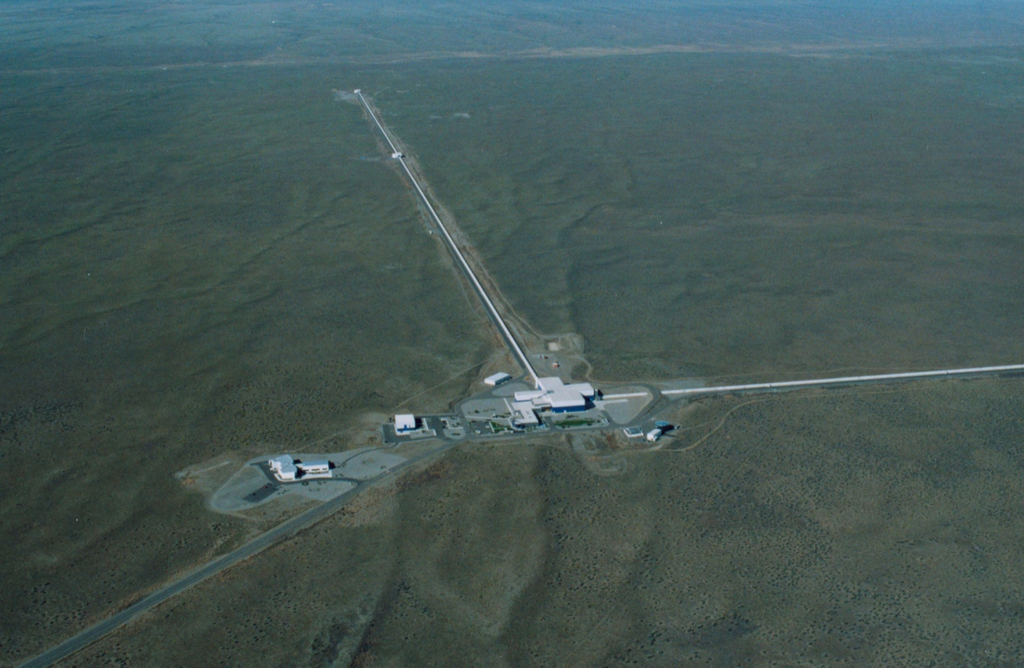

美国华盛顿州汉福德站航拍。中央站位于画面中下方，两条臂分别向左上方和右侧延伸。

[照片：Caltech/MIT/LIGO Lab，2008 年](https://www.ligo.caltech.edu/image/ligo20150731e)

**先找两条臂的交点**

从画面中下方的中央站看，一条臂伸向左上方，另一条向右延伸至画面外。两臂在地面上相互垂直。

**沿着光走一个来回**

激光在中央站分成两束，沿两臂往返后回到这里。比较返回光的相位，就能读出两臂长度差的微小变化。

# 引力波怎样改变干涉仪的读数

留意两束光返回分束器时，两臂长度差的变化怎样体现在干涉信号上。

[video not shown]

# 从臂长差的干涉信号到读出噪声

臂长差改变，两束返回光的相位差也改变。探测器根据干涉光强读出这个变化（虚线）。

**普通真空。** 用光子计数测光强时，计数的随机起伏使相位读数（蓝线）偏离虚线。

**相位压缩真空。** 从读出端送入相位涨落更小的真空，同一信号周围的散粒噪声就减小。

高频读出模拟 · 两图的相位读数采用同一刻度

# 干涉仪在不同频段需要不同的压缩方向

刚才看到的是臂长差快速变化时的读出。臂长差缓慢变化时，还要考虑端镜受到的推力。

[figure not shown]

**高频 · 看读出端**  
沿相位方向压缩，减小散粒噪声对干涉信号的影响。

**低频 · 看端镜**  
光的振幅涨落使辐射压力起伏。相同大小的力缓慢变化时，端镜位移更大，会干扰臂长差的测量。

压低相位涨落会增大振幅涨落。滤波腔使压缩方向随频率转动，高频侧重压相位，低频侧重压振幅。

# 从干涉仪构想到双中子星探测距离

**1981 年** Caves 提出利用未使用输入端的量子态改善干涉测量。

**2013 年** 公里级 LIGO 干涉仪验证了压缩光对灵敏度的改善。

**2019 年** Advanced LIGO 在第三轮观测中使用压缩真空，降低高频散粒噪声。

**2023 年** 两站各使用约 300 米长的滤波腔，实现随频率改变压缩方向。

综合各频段的灵敏度改善，与未注入压缩光相比，两站对双中子星并合信号的探测距离提高约 **15%–18%**。

[Caves, Phys. Rev. D (1981)](https://doi.org/10.1103/PhysRevD.23.1693) · [Aasi 等 (2013)](https://doi.org/10.1038/nphoton.2013.177) · [Tse 等 (2019)](https://doi.org/10.1103/PhysRevLett.123.231107) · [Ganapathy 等, Phys. Rev. X (2023)](https://doi.org/10.1103/PhysRevX.13.041021)

# 思考题 9 干涉仪的压缩方向

在同时受到光子散粒噪声和辐射压噪声影响的干涉仪中，为什么要考虑让压缩方向随频率改变？

B。高频主要受散粒噪声限制，低频的量子反作用更重要。让压缩轴随频率转动，可以兼顾两者。

# 从真空基准到压缩光

留意片里的两次转动。调本振相位时，变的是什么？调泵浦相位时呢？

[video not shown]

# 回到真空涨落：一个分量可以比真空更安静

| 在同一模式上做的比较 | 结果 |
| --- | --- |
| 固定本振相位，换入压缩光 | 选中压缩轴时，计数差的方差低于真空 |
| 保持光源不变，本振相位从压缩轴再转 $\pi/2$ | 读到正交方向较大的涨落 |
| 对比两个分量的标准差乘积 | 理想压缩真空与真空都达到下限 $1/4$ |

真空使模式的总能量最低。压缩光借助泵浦输入的能量重新分配两个分量的涨落，因此可以降低选定分量的噪声。

## 补充：真空能量最低与分量压缩可以同时成立

对同一频率的模式，$\hat H=\hbar\omega(\hat n+1/2)$。把 $\hat a=\hat X+i\hat Y$ 代回 $\hat n=\hat a^\dagger\hat a$，由 $[\hat X,\hat Y]=i/2$ 得到

$$\hat n=(\hat X-i\hat Y)(\hat X+i\hat Y)=\hat X^2+\hat Y^2+i[\hat X,\hat Y]=\hat X^2+\hat Y^2-\tfrac12.$$

理想压缩真空的两个分量均值都为零，故 $\langle\hat n\rangle=(e^{-2r}+e^{2r}-2)/4=\sinh^2r$。

$r>0$ 时，两个方差的和增大，模式的平均能量高于真空。一个分量的方差仍可低于真空基准。

# 一键三连

[figure not shown]